# DATA5002 Assignment 1

Seoyeon Park(z5248219)

```r
if (!require("socialmixr")) install.packages("socialmixr")
library(socialmixr)
data(polymod)

library(dplyr)
## A table with all participants and their contacts in 'long' format, where
## participants with 0 contacts get a single row for which cont_id is NA.
allpartcont <- left_join(polymod$participants, polymod$contacts)
## A table with all participants and their contacts in 'long' format, where
## participants with 0 contacts are dropped.
partcont <- inner_join(polymod$participants, polymod$contacts)
## Participants without contacts have been dropped:
partcont %>%
    filter(is.na(cont_id)) %>%
    select(part_id:part_occupation, country, hh_size, sday_id:cnt_gender)
```

| part_id | hh_id | part_age | part_gender | part_occupation | country | hh_size | sday_id | type | day | month | year | dayofweek | cont_id | cnt_age_exact | cnt_age_est_min | cnt_age_est_max | cnt_gender |
| --- | --- | --- | --- | --- | --- | --- | --- | --- | --- | --- | --- | --- | --- | --- | --- | --- | --- |

# Question 1

## (a)

**Question:** How do the distributions of the numbers of contacts per person vary from country to country, and is there a gender difference within each country?

**Note:** Some participants have blank for gender. You may either omit them or include them in the visualisation; if the latter, clearly indicate that their gender is missing.

**Choice of chart**

- Since we are interested in the distribution of number of contacts from country to country and by gender, box plots are chosen as it effectively visualizes many distributions at once ([Wilke (2019) *Fundamentals of Data Visualization*](https://clauswilke.com/dataviz/), Chapters 5).
- In addition, the box plot is appropriate in the sense that the target audience is an academic or science popularization publication who should be assumed to be able to interpret the box plot.
- The plot uses two position scales and one color scale. The variable “country” is mapped onto the x-axis, the number of contacts per person onto the y-axis, gender is mapped by color to show how the distributions of number of contacts vary across different countries and genders.
- The colors hue scale (ggplot2 default) are chosen to clearly distinguish the gender, male and female while no single color stands out relative to the other or gives any impression of a specific order.

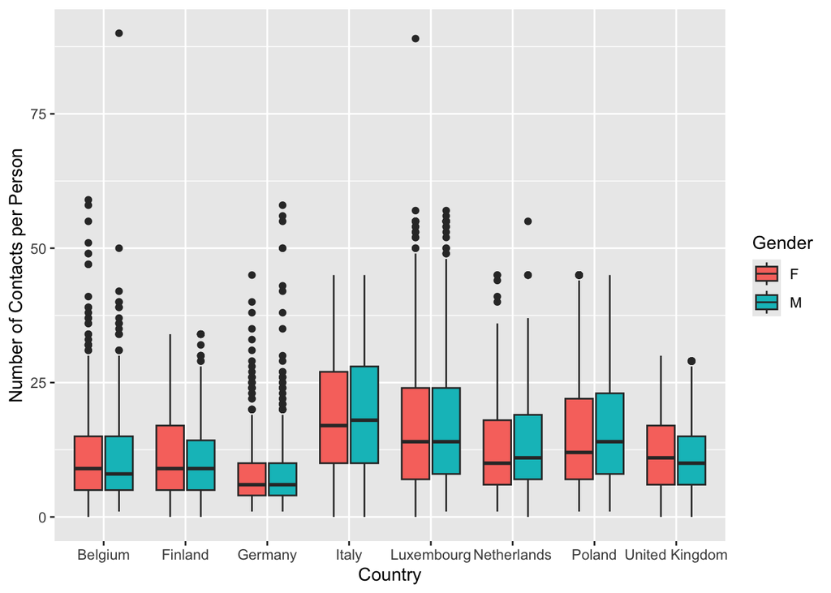

```r
library(ggplot2)
library(dplyr)

allpartcont <- left_join(polymod$participants, polymod$contacts)
cnt_per_person <- allpartcont %>%
  group_by(part_id) %>%
  summarise(cnt_counts = ifelse(all(is.na(cont_id)), 0, n())) %>%
  left_join(allpartcont, by = "part_id") %>%
  select(part_id, cnt_counts, part_gender, country) %>%
  distinct(part_id, cnt_counts, part_gender, country) %>%
  filter(!is.na(part_gender) & part_gender != "")

ggplot(cnt_per_person, aes(factor(country), cnt_counts, fill = part_gender)) +
  geom_boxplot() +
  labs(x = "Country",
       y = "Number of Contacts per Person",
       fill = "Gender")
```

**Conclusion:**

How do the distributions of the numbers of contacts per person vary from country to country, and is there a gender difference within each country?

- The distribution of the number of contacts per person significantly vary from country to country. For example, Italy and Luxembourg show wide distribution with higher median number of contacts whereas, Germany has a narrow distribution with much smaller median number of contacts across the country.
- Belgium and Finland, have notably similar distributions whereas the Netherlands, Poland and the UK are each more unique in their individual distribution numbers and shape.
- There is no significant gender difference in the distribution of each country. For instance Germany shows almost identical distributions across genders whilst some minimal differences exist between genders in remaining countries.

## (b)

**Question:** How do the *means* of the numbers of contacts per person vary from country to country and by gender? Also include information to let the viewer quickly assess if the difference may be statistically significant.

**Choice of chart**

- Similarly in this chart, the variable “country” is mapped along the x-axis, means of the number of contacts per person onto the y axis, gender mapped by color and the colors hue scale (ggplot2 default) are used to clearly distinguish the male and female without one color standing out or giving any impression of on order.
- Each mean number of contacts is represented by a dot shape to visually emphasize the position of the mean within the confidence interval.
- The means within each gender are connected by a line to efficiently show whether the differences are statistically significant from country to country and let the viewer quickly assess its significance.
- The confidence interval are shown in an I-shape to effectively check the overlap from country to country and by gender.
- For each country, the plotted distance between each gender is set to 0.1 to position the error bars next to each other rather than overplotting in order to easily capture the mean differences by gender.

```r
library(broom)

mean_CIs <- cnt_per_person %>%
  group_by(country, part_gender) %>%
  summarise(
   CI95 = tidy(t.test(cnt_counts, conf.level = 0.95))
  )
```

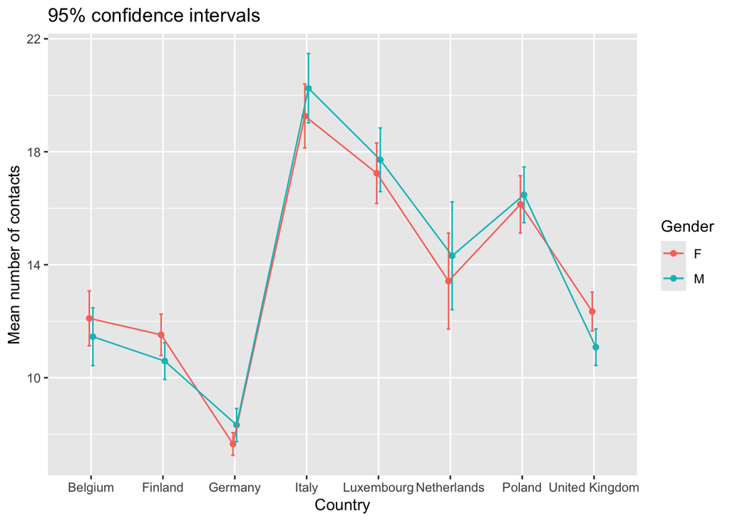

```r
dodge <- position_dodge(0.1)

ggplot(mean_CIs, aes(y = CI95$estimate, x = country, col = part_gender, group = part_gender)) +
  geom_errorbar(aes(ymin = CI95$conf.low, ymax = CI95$conf.high), width = .1, position = dodge) +
  geom_point(position = dodge) +
  geom_line(position = dodge) +
  labs(x = "Country",
       y = "Mean number of contacts",
       col = "Gender",
       title = "95% confidence intervals")
```

**Conclusion**

How do the *means* of the numbers of contacts per person vary from country to country and by gender? Also include information to let the viewer quickly assess if the difference may be statistically significant.

- In the above plot, the pink line and blue line have similar patterns though there are some slight differences. In addition, the confidence intervals within each country are overlapping. Therefore, gender as a variable does not have a significant impact on the mean value and so the mean of the number of contacts per person do not vary by gender.
- Both the pink line and blue line values vary up and down greatly across countries. For example, the mean peaks at Italy and troughs at Germany and displays a large difference showing that the means significantly vary between countries. Furthermore, the fact that there are less overlappings in confidence intervals across countries evidently shows that country as a variable has a statistically significant impact on means of the number of contacts per person.

## (c)

**Question:** What fraction of contacts occurred in which type of setting, breaking down by country?

**Target Audience:** General public, e.g., illustration to a newspaper article.

```r
library(tidyr)
partcontset <- partcont %>%
    rowwise() %>%
    mutate(cnt_nsettings = sum(c_across(cnt_home:cnt_otherplace))) %>%
    mutate(across(cnt_home:cnt_otherplace, function(x) x/cnt_nsettings)) %>%
    #select(-cnt_nsettings) %>%
    pivot_longer(cnt_home:cnt_otherplace, names_to = "cnt_setting", names_prefix = "cnt_",
        values_to = "cnt_setting_frac") %>%
    filter(cnt_setting_frac > 0) %>%
    mutate(cnt_setting = ifelse(cnt_setting == "otherplace", "other", cnt_setting))
```

```r
frac_setting_country <- partcontset %>%
  group_by(country, cnt_setting) %>%
  summarise(setting_contacts = sum(cnt_setting_frac)) %>%

  group_by(country) %>%
  mutate(cnts_in_country = sum(setting_contacts)) %>%
  mutate(country_setting_cnts_frac = setting_contacts / cnts_in_country) %>%
  select(-cnts_in_country, -setting_contacts)
```

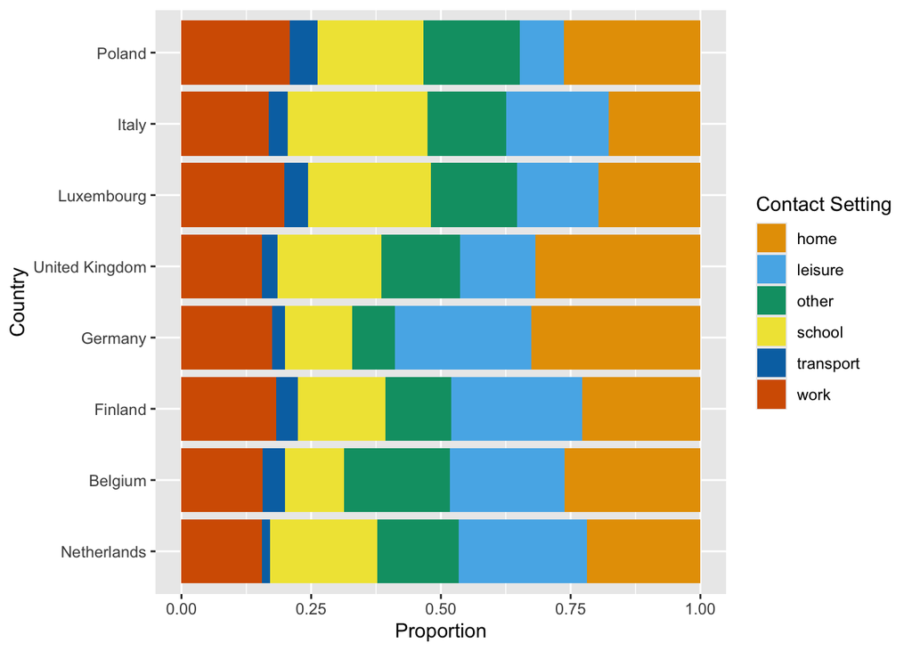

```r
frac_setting_country$country <- factor(frac_setting_country$country,
                                       levels = c("Netherlands", "Belgium", "Finland",
                                                  "Germany", "United Kingdom",
                                                  "Luxembourg", "Italy", "Poland"))

#frac_setting_country
okabe_ito <- c("#E69F00", "#56B4E9", "#009E73", "#F0E442", "#0072B2", "#D55E00", "#CC79A7")

ggplot(frac_setting_country, aes(country_setting_cnts_frac, country, fill = cnt_setting)) +
  geom_bar(stat = "identity", position = "fill") +
  labs(x = "Proportion", y = "Country", fill = "Contact Setting") +
  scale_fill_manual(values = okabe_ito)
```

**Question:** What fraction of contacts occurred in which type of setting, breaking down by country?

# Question 2

Now, suppose that we would like to predict the number of contacts a participant has (and hence their propensity to be infected or to infect others) as a function of their various demographics included in the dataset, which include the participant’s age, gender, occupation, country, household size, if they are a child and if so if they are in child care, and others, as well as the day of the week of the diary (particularly weekend).

**Notes:**

- Keep in mind that for small children, some of the answers pertain to their guardian. Refer to the data dictionary for which ones.
- Some of the values are stored as numeric codes. Refer to the data dictionary, and recode them for regression.

**Target Audience:** The assumed audience for the plots for this question is either creating plots for your own exploration, or for sharing with a single colleague with similar technical knowledge.

## (a)

Fit either a linear or a log-linear (Poisson) regression model for the number of contacts a participant has (which may be 0) on at least 3 predictors. Print out the `summary()` of the model.

When considering what variables to choose for the regression model, think about variables you would choose for prediction, e.g., which variables might be available in a census. You can use stepwise selection (`? step`), or some other reasonable approach. Keep in mind that quantitative predictors (e.g., household size, age) may have nonlinear effects.

if they are a child and if so if they are in child care

- Keep in mind that for small children, some of the answers pertain to their guardian. Refer to the data dictionary for which ones.

```r
participant <- allpartcont %>%
  group_by(part_id) %>%
  summarise(numOfcontacts = ifelse(all(is.na(cont_id)), 0, n()))

participant <- left_join(polymod$participants, participant) %>%
  mutate(pertain_guardian = ifelse(type == 3, 1, 0)) %>%
  mutate(is_child_in_care = ifelse(part_age > 18, "Oth",
                           ifelse(part_age < 18 & child_care == "Y", "Y", "N"))) %>%
  select(numOfcontacts, part_age, part_gender, part_occupation, country, hh_size, is_child_in_care, pertain_guardian, dayofweek) %>%
  mutate(
    part_occupation = as.factor(part_occupation),
    is_child_in_care = as.factor(is_child_in_care),
    pertain_guardian = as.factor(pertain_guardian),
    dayofweek = as.factor(dayofweek)
  )
participant <- na.omit(participant)

glm_8 <- glm(numOfcontacts ~ ., family = quasipoisson, data = participant)
summary(glm_8)
```

```
##
## Call:
## glm(formula = numOfcontacts ~ ., family = quasipoisson, data = participant)
##
## Coefficients:
##                         Estimate Std. Error t value Pr(>|t|)
## (Intercept)            2.5427977  0.2247176  11.316  < 2e-16 ***
## part_age              -0.0023407  0.0008661  -2.702  0.00690 **
## part_genderF          -0.2496676  0.2177424  -1.147  0.25158
## part_genderM          -0.2817630  0.2178113  -1.294  0.19584
## part_occupation2      -0.4235366  0.0366823 -11.546  < 2e-16 ***
## part_occupation3      -0.3293490  0.0390186  -8.441  < 2e-16 ***
## part_occupation4      -0.3835877  0.0450500  -8.515  < 2e-16 ***
## part_occupation5      -0.0889451  0.0290323  -3.064  0.00219 **
## part_occupation6      -0.2106734  0.0445615  -4.728 2.32e-06 ***
## countryFinland        -0.0520783  0.0349440  -1.490  0.13618
## countryGermany        -0.3191339  0.0355017  -8.989  < 2e-16 ***
## countryItaly           0.4907709  0.0323998  15.147  < 2e-16 ***
## countryLuxembourg      0.3725931  0.0320537  11.624  < 2e-16 ***
## countryNetherlands     0.2075189  0.0482528   4.301 1.73e-05 ***
## countryPoland          0.3205378  0.0324281   9.885  < 2e-16 ***
## countryUnited Kingdom -0.0107515  0.0351176  -0.306  0.75950
## hh_size                0.0730490  0.0063866  11.438  < 2e-16 ***
## is_child_in_careOth   -0.1575293  0.0338320  -4.656 3.28e-06 ***
## is_child_in_careY      0.3007638  0.0584672   5.144 2.76e-07 ***
## pertain_guardian1     -0.5919230  0.0620027  -9.547  < 2e-16 ***
## dayofweek1             0.3178249  0.0336201   9.453  < 2e-16 ***
## dayofweek2             0.3672660  0.0328238  11.189  < 2e-16 ***
## dayofweek3             0.3718579  0.0331706  11.210  < 2e-16 ***
## dayofweek4             0.3720652  0.0327572  11.358  < 2e-16 ***
## dayofweek5             0.3821826  0.0325235  11.751  < 2e-16 ***
## dayofweek6             0.1438691  0.0353902   4.065 4.85e-05 ***
## ---
## Signif. codes:  0 '***' 0.001 '**' 0.01 '*' 0.05 '.' 0.1 ' ' 1
##
## (Dispersion parameter for quasipoisson family taken to be 5.862636)
##
##     Null deviance: 51612  on 6944  degrees of freedom
## Residual deviance: 36404  on 6919  degrees of freedom
## AIC: NA
##
## Number of Fisher Scoring iterations: 5
```

- The p-values of gender for both levels are greater than 0.05 which are 0.25158 and 0.19584 respectively. Therefore we do not reject the null hypothesis and conclude that gender is not significant at significance level, 0.05 when predicting number of contacts. Hence the gender feature has been dropped.

```r
glm_7 <- glm(numOfcontacts ~ part_age + part_occupation+country+hh_size+is_child_in_care+pertain_guardian+dayofweek, family = quasipoisson, data = participant)

drop1(glm_7)
```

|  | Df | Deviance |
| --- | --- | --- |
|  | NA | 36435.39 |
| part_age | 1 | 36480.72 |
| part_occupation | 5 | 37823.81 |
| country | 7 | 42236.25 |
| hh_size | 1 | 37182.54 |
| is_child_in_care | 2 | 36690.16 |
| pertain_guardian | 1 | 36985.81 |
| dayofweek | 6 | 37871.33 |

- All the variables used in glm_7 are significant as deviance has been increased after removing each variable.
- Therefore, none of the feature sets are dropped and so final model would be glm_7.

```r
summary(glm_7)
```

```
##
## Call:
## glm(formula = numOfcontacts ~ part_age + part_occupation + country +
##     hh_size + is_child_in_care + pertain_guardian + dayofweek,
##     family = quasipoisson, data = participant)
##
## Coefficients:
##                         Estimate Std. Error t value Pr(>|t|)
## (Intercept)            2.2779797  0.0560565  40.637  < 2e-16 ***
## part_age              -0.0024068  0.0008653  -2.782  0.00543 **
## part_occupation2      -0.4214419  0.0366565 -11.497  < 2e-16 ***
## part_occupation3      -0.3150429  0.0384035  -8.203 2.76e-16 ***
## part_occupation4      -0.3812247  0.0450219  -8.468  < 2e-16 ***
## part_occupation5      -0.0861940  0.0289876  -2.973  0.00295 **
## part_occupation6      -0.2088986  0.0445689  -4.687 2.82e-06 ***
## countryFinland        -0.0513752  0.0349330  -1.471  0.14142
## countryGermany        -0.3187197  0.0354883  -8.981  < 2e-16 ***
## countryItaly           0.4887631  0.0323750  15.097  < 2e-16 ***
## countryLuxembourg      0.3709824  0.0320292  11.583  < 2e-16 ***
## countryNetherlands     0.2054641  0.0482300   4.260 2.07e-05 ***
## countryPoland          0.3184458  0.0324025   9.828  < 2e-16 ***
## countryUnited Kingdom -0.0126070  0.0350952  -0.359  0.71944
## hh_size                0.0729310  0.0063854  11.421  < 2e-16 ***
## is_child_in_careOth   -0.1543480  0.0337845  -4.569 4.99e-06 ***
## is_child_in_careY      0.2983381  0.0584673   5.103 3.44e-07 ***
## pertain_guardian1     -0.5914634  0.0619962  -9.540  < 2e-16 ***
## dayofweek1             0.3174596  0.0336121   9.445  < 2e-16 ***
## dayofweek2             0.3675987  0.0328057  11.205  < 2e-16 ***
## dayofweek3             0.3717824  0.0331633  11.211  < 2e-16 ***
## dayofweek4             0.3716513  0.0327452  11.350  < 2e-16 ***
## dayofweek5             0.3817912  0.0325157  11.742  < 2e-16 ***
## dayofweek6             0.1440764  0.0353728   4.073 4.69e-05 ***
## ---
## Signif. codes:  0 '***' 0.001 '**' 0.01 '*' 0.05 '.' 0.1 ' ' 1
##
## (Dispersion parameter for quasipoisson family taken to be 5.860109)
##
##     Null deviance: 51612  on 6944  degrees of freedom
## Residual deviance: 36435  on 6921  degrees of freedom
## AIC: NA
##
## Number of Fisher Scoring iterations: 5
```

## (b)

Create at least 2 diagnostic plots for the regression model and comment on what each plot says about the model fit. For each plot, conclude whether there are any potential violations of linear model assumptions. Note: only the first 2 diagnostic plots will be marked

```r
library(broom)
library(ggrepel)
```

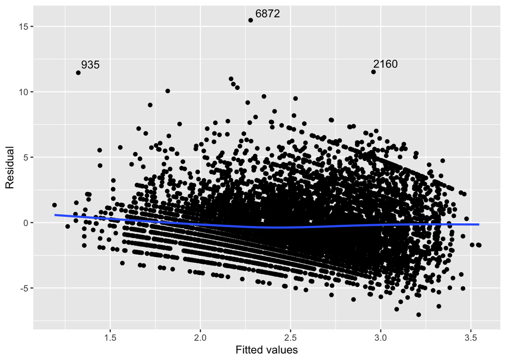

```r
participantaug <- augment(glm_7, participant)

high_abs_resid <- rank(-abs(participantaug$.std.resid)) <= 3

ggplot(participantaug, aes(x = .fitted, y = .resid,
                   label = ifelse(high_abs_resid,
                                  seq_along(high_abs_resid), NA))) +
  geom_point() +
  geom_smooth(se = FALSE) +
  geom_text_repel() +
  labs("Residuals vs. Fitted Plot",
       x = "Fitted values",
       y = "Residual")
```

- In Residuals vs Fitted, while the residuals are mostly centered around zero, however there is a slight convex curve suggesting that the linear model does not fully capture the underlying relation between predictors and response variable such as non-linear effect. Therefore, the linearity assumption may not hold. The quantitative predictor such as household size or age could have a non-linear relationship between the number of contacts and this could be addressed by transforming the feature.

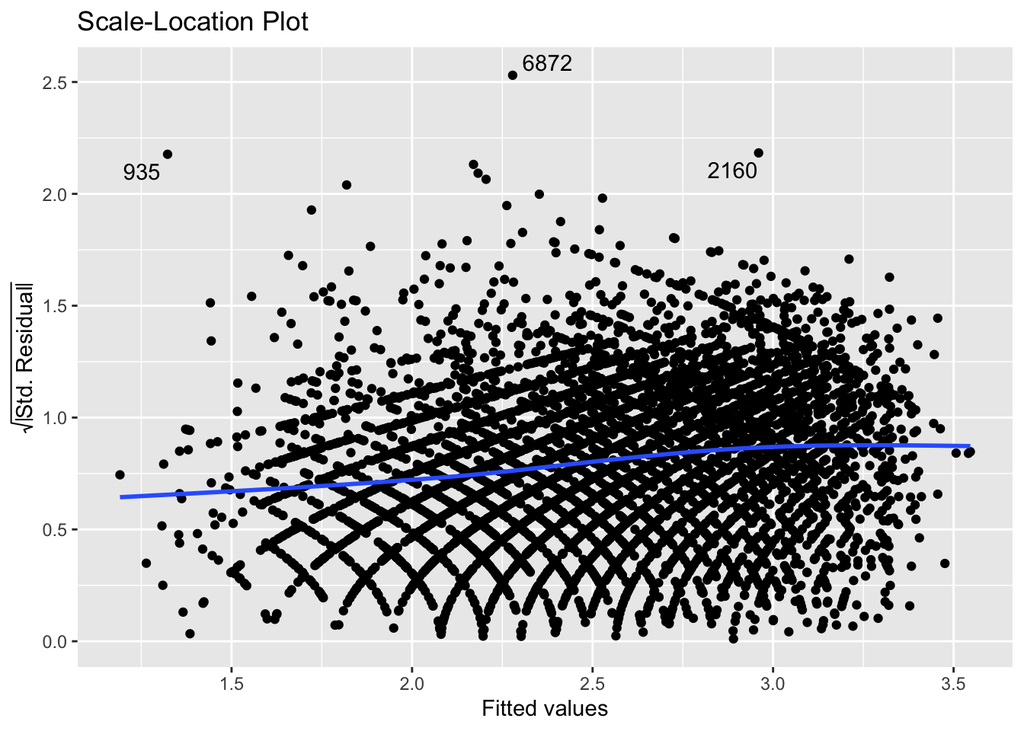

```r
ggplot(participantaug, aes(x = .fitted, y = sqrt(abs(.std.resid)),
                   label = ifelse(high_abs_resid,
                                  seq_along(high_abs_resid), NA))) +
  geom_point() +
  geom_smooth(se = FALSE) +
  geom_text_repel() +
  labs(title = "Scale-Location Plot",
       x = "Fitted values",
       y = expression(sqrt(abs("Std. Residual"))))
```

- In the **Scale-Location** plot, although the blue line is relatively flat, there is a slightly upward trend suggesting that as the fitted values increase, the variance of the residuals might slightly increase as well. Therefore, this could indicate the violation of the equal variance (homoscedasticity) assumption.

## (c)

Create a forest plot of the model coefficients in your regression model. State your conclusions about the relationship between each variable in your regression and the predicted average number of contacts.

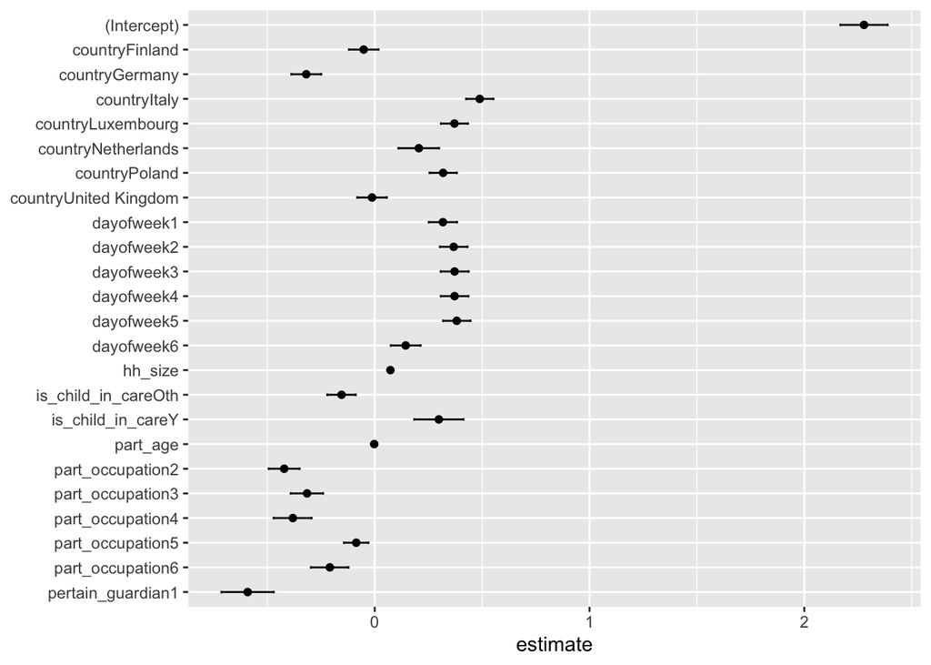

```r
library(broom)

tidy(glm_7, conf.int = TRUE) %>%
  ggplot(aes(y = term, x = estimate, xmin = conf.low, xmax = conf.high)) +
  geom_point() +
  geom_errorbar(width = .1) + labs(y = NULL) +
  scale_y_discrete(limits = rev)
```